[figure not shown]

### ENSIMAG -- 2A

# Optimisation Numérique

## TP : Linear and Quadratic programs (1.5h)

# Structure of an optimization program

An optimization program can be practically divided into three parts:

- the *run* environment, in which you test, run your program, and display results.
- the *problem* part, which contains the function oracles, problem constraints, etc.
- the *algorithmic* part, where the algorithms are coded.

The main interest of such division is that these parts are interchangeable, meaning that, for instance, the algorithms of the third part can be used of a variety of problems. That is why such a decomposition is widely used.

In the present lab, you will use this division:

- `LP_and_QP_problems.ipynb` will be the *run* environment
- `toy_problem.ipynb` and `imaging.ipynb` will be the considered *problems* for this lab
- the library `cvxopt` will be used for solving all optimization problems

The following script will allow you to import *notebooks* as if you imported *python files* and will have to be executed at each time you launch Jupyter notebooks.

```python
import start
from imp import reload
```

# Regression model

We consider the regression model

$$ y=X\theta+\xi,\;\;\xi\sim \mathcal{N}(0, \sigma I_m), $$

where $X\in \mathbb{R}^{m\times n}$ and $y\in \mathbb{R}^m$ are the observed values and $\theta\in \mathbb{R}^n$ is the unknown parameter we want to find.

We want to find a value $\widehat{\theta}$ such that

- the quadratic error $e(\widehat{\theta}) = 1/2 \|X\widehat{\theta} - y \|_2^2$ is (near)-minimal, that is $ \| \nabla e(\widehat{\theta}) \| = \| X^\mathrm{T} (X\widehat{\theta} - y) \| $ is small.

# the Dantzig Selector

The **Dantzig Selector** for $\theta$, introduced in *Emmanuel Candes and Terrence Tao "The Dantzig selector: Statistical estimation when $p$ is much larger than $n$". The Annals of Statistics, 2007* can be used to estimate $\theta$ in the case of an overparametrized problem, i.e. when the dimension $n$ of $\theta$ is well greater than the dimension of the observation $y$.

In that case, the estimator $\widehat{\theta}_{DS}$ is the solution of the optimization problem $$ \widehat{\theta}_{DS} \in \arg\min_{\theta\in \mathbb{R}^n} \left\{\|\theta\|_1,\;\mbox{with}\;\|X^T(X\theta-y)\|_\infty\leq \kappa\sigma\right\}, $$ where $\kappa>0$ is an *hyper-parameter*.

The best theoretical value for $\kappa$ is $\nu q_{\mathcal{N}} \left(1-\frac{\alpha}{2n}\right)$, where $\alpha\in(0,1)$ is the chosen risk level (e.g. $\alpha=.05$), $q_\mathcal{N}(p)$ is the $p$-quantile of the standard normal distribution, and $\nu=\max_j\|[X]_j\|_2$ is the maximal column norm of matrix $X$.

**Objective:** Implement a function that return the Dantzig estimator $\widehat{\theta}_{DS}$ from input $(y,X,\sigma)$ using linear programming solver `cvxopt`.

> Reformulate the $\arg\min$ problem as a linear program.

> Write a function `DantzigSelector` that takes `y,X,sigma` as an input and outputs $\widehat{\theta}_{DS}$ by using the linear program solver of the library `cvxopt` [lp](http://cvxopt.org/userguide/coneprog.html#linear-programming) which, given $c, G, h$ solves the problem $$ \min_x c^\mathrm{T}x ~~~~~~ \text{ subject to } Gx \leq h $$ where the inequality is elementwise.

*Hint: Useful functions are* `np.concatenate` `np.zeros` `np.eye` `np.hstack` `np.vstack`

If we put the problem in a linear form we have :

$$ \left\{ \begin{array}{ll} \min \sum^{n}_{i=1} s_i \\ \text{such as} \ \forall \ \theta \in \mathbb{R^{n}} \ \text{s} \in \mathbb{R^{n}} \\ \forall i \in \{ \text{1,...,n} \} \\ \theta_i \leq s_i \\ - \theta_i \leq s_i \\ [A^T(A\theta-y)]_i \leq K\sigma \\ -[A^T(A\theta-y)]_i \leq K\sigma \end{array} \right. $$

the canonical form is: $$ \min_{x \in \mathbb{R^{2n}} } c^\mathrm{T}x ~~~~~~ \text{ subject to } Gx \leq h $$

where

$ s= \begin{bmatrix} s_1 \\ . \\ . \\ . \\ s_n \end{bmatrix} \in \mathbb{R^{n}} $

$ \theta= \begin{bmatrix} \theta_1 \\ . \\ . \\ . \\ \theta_n \end{bmatrix} \in \mathbb{R^{2n}} $

$ c = \begin{bmatrix} 0 \\ . \\ . \\ . \\ 0 \\ 1 \\ . \\ . \\ . \\ 1 \end{bmatrix} \in \mathbb{R^{2n}} $

$ x = \begin{bmatrix} \theta \\ s \end{bmatrix} \in \mathbb{R^{2n}} $

$ G = \begin{bmatrix} X^TX&0 \\ -X^TX&0 \\ I_n&-I_n \\ -I_n&-I_n \end{bmatrix} \in M_{4n,2n}( \mathbb{R^{3n}}) $

$ h= \begin{bmatrix} K\sigma + [X^Ty]_1 \\ . \\ . \\ . \\ K\sigma + [X^Ty]_n \\ K\sigma - [X^Ty]_1 \\ . \\ . \\ . \\ K\sigma - [X^Ty]_n \\ 0 \\ . \\ . \\ . \\ 0 \end{bmatrix} \in \mathbb{R^{4n}} $

```python
from cvxopt import matrix, solvers, sparse

from scipy.stats import norm
import numpy as np

def DantzigSelector(y,X,sigma):

    # Extracting the sizes
    m,n = X.shape

    # Computing kappa
    alpha = 0.05
    nu = max(np.linalg.norm(X, axis=0))
    kappa = nu*norm.ppf(1-alpha/(2.0*n))


    #####################################################
    # COMPUTE AND SOLVE LP PROBLEM
    #####################################################

    XTX = np.transpose(X).dot(X)
    Id = np.identity(n)
    O = np.zeros((n,n))
    G = np.hstack((np.vstack((XTX,-XTX, Id, -Id)),np.vstack((O, O, -Id, -Id))))


    c = np.vstack((np.zeros((n,1)), np.ones((n,1), dtype=np.double)))

    XTy = np.transpose(X).dot(y)

    h = np.vstack((XTy+kappa*sigma,-XTy+kappa*sigma,np.zeros((n)),np.zeros((n))))
    h = np.reshape(h,(4*n,1))


    h = matrix(h)
    c = matrix(c)
    G = matrix(G)

    theta = solvers.lp(c,G,h)

    return theta['x'][:n]
```

> Test your code on the toy problem given in `toy_problem.ipynb`. For this randomly generated problem, there is a true $\theta$ upon which the problem is built.

```python
import toy_problem as tPb
reload(tPb)

#theta_test = DantzigSelector(8*np.ones((5)),2*np.identity(5),1)

theta_ds = DantzigSelector(tPb.y,tPb.X,tPb.sigma)

#print((abs(theta_ds-tPb.theta) < 0.05))

#print(np.hstack((theta_ds, np.reshape(tPb.theta, (tPb.n,1)))))
```

```
importing notebook from toy_problem.ipynb
importing notebook from toy_problem.ipynb
     pcost       dcost       gap    pres   dres   k/t
 0:  0.0000e+00 -2.1191e+02  2e+03  4e+00  2e+00  1e+00
 1:  3.9590e+00 -3.2326e+01  1e+02  7e-01  4e-01  3e+00
 2:  1.8016e+00 -7.5923e+00  3e+01  2e-01  1e-01  7e-01
 3:  1.8237e+00 -4.8848e+00  2e+01  1e-01  7e-02  4e-01
 4:  2.3489e+00  5.3025e-01  5e+00  3e-02  2e-02  8e-02
 5:  2.6314e+00  2.3097e+00  9e-01  6e-03  3e-03  6e-03
 6:  2.6811e+00  2.5379e+00  4e-01  2e-03  1e-03  2e-03
 7:  2.7211e+00  2.7180e+00  8e-03  5e-05  3e-05  2e-05
 8:  2.7221e+00  2.7221e+00  8e-05  5e-07  3e-07  2e-07
 9:  2.7221e+00  2.7221e+00  8e-07  5e-09  3e-09  2e-09
Optimal solution found.
```

> Investigate the differences between the Dantzig selector and the Ground truth

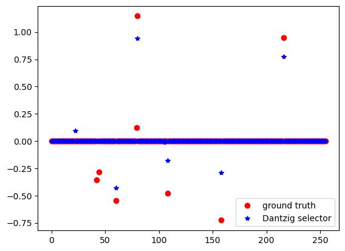

```python
import matplotlib.pyplot as plt
%matplotlib inline

plt.figure()
plt.plot(tPb.theta,'ro',label='ground truth')
plt.plot(theta_ds,'b*',label='Dantzig selector')
plt.legend()
plt.show()
```

# the Lasso

Under the same regression model, the Least Absolute Shrinkage and Selection Operator or **lasso** for $\theta$, introduced in *Robert Tibshirani "Regression shrinkage and selection via the lasso", Journal of the Royal Statistical Society, 1996* can also be used to estimate $\theta$.

The estimator $\widehat{\theta}_{L}$ is the solution of the optimization problem $$ \widehat{\theta}_{L} \in \arg\min_{\theta\in \mathbb{R}^n} \left\{ \|X\theta - y\|_2^2 + \kappa \sigma \|\theta\|_1 \right\}, $$ where $\kappa>0$ is an *hyper-parameter*.

The best theoretical value for $\kappa$ is the same as for the Dantzig selector: $\nu q_{\mathcal{N}} \left(1-\frac{\alpha}{2n}\right)$, where $\alpha\in(0,1)$ is the chosen risk level (e.g. $\alpha=.05$), $q_\mathcal{N}(p)$ is the $p$-quantile of the standard normal distribution, and $\nu=\max_j\|[X]_j\|_2$ is the maximal column norm of matrix $X$.

**Objective:** Implement a function that return the lasso estimator $\widehat{\theta}_{L}$ from input $(y,X,\sigma)$ using quadratic programming solver `cvxopt`.

> Reformulate the $\arg\min$ problem as a quadratic program.

> Write a function `Lasso` that takes `y,X,sigma` as an input and outputs $\widehat{\theta}_{L}$ by using the quadratic program solver of the library `cvxopt` [qp](http://cvxopt.org/userguide/coneprog.html#quadratic-programming) which, given $P,q, G, h$ solves the problem $$ \min_x 1/2 x^\mathrm{T} P x + q^\mathrm{T}x ~~~~~~ \text{ subject to } Gx \leq h $$ where the inequality is elementwise.

*Hint: Useful functions are* `np.concatenate` `np.zeros` `np.eye` `np.hstack` `np.vstack`

Reformulation:

First we have

$$\min_\theta \{ ||X\theta||^2_2 + \kappa\sigma||\theta||_1 \}$$$$\iff$$$$ \left\{ \begin{array}{ll} \min_{(\theta,s) \in \mathbb{R^{2n}}} \{ ||X\theta||^2_2 + \kappa\sigma\sum_{i=1}^n s_i \} \\ \text{such that} \\ \forall i \in \{1 \text{,...,} n\} \\ \theta_i \leq s_i \\ -\theta_i \leq s_i \end{array} \right. $$

Second we have

$$||X\theta||^2_2 = \theta^T X^TX \theta - \theta^TX^Ty - y^TX\theta - ||y||^2_2$$

and

$$ - \theta^TX^Ty - y^TX\theta = - \sum_{1 \leq i,j \leq n} \theta_iX^T_{i,j}y_j + y_jX_{j,i}\theta_i = - \sum_{1 \leq i \leq n} \sum_{1 \leq j \leq n} (X_{j,i} + X_{j,i})y_j\theta_i = - \sum_{1 \leq i \leq n} 2 X_i^T y\theta_i $$

with $X_i$ the i-th column of $X$

So we get

$$ \left\{ \begin{array}{ll} \min_{(\theta,s) \in \mathbb{R^{2n}}} \{ ||X\theta||^2_2 + \kappa\sigma\sum_{i=1}^n s_i \} \\ \text{such that} \\ \forall i \in \{1 \text{,...,} n\} \\ \theta_i \leq s_i \\ -\theta_i \leq s_i \end{array} \right. $$$$\iff$$$$ \left\{ \begin{array}{ll} \min_{(\theta,s) \in \mathbb{R^{2n}}} \{ \theta^T X^TX \theta + \sum_{1 \leq i \leq n} -2 x_i^T y_j\theta_i - ||y||^2_2 + \kappa\sigma\sum_{i=1}^n s_i \} \\ \text{such that} \\ \forall i \in \{1 \text{,...,} n\} \\ \theta_i \leq s_i \\ -\theta_i \leq s_i \end{array} \right. $$

hence

$$ \left\{ \begin{array}{ll} arg \min_{(\theta,s) \in \mathbb{R^{2n}}} \{ ||X\theta||^2_2 + \kappa\sigma\sum_{i=1}^n s_i \} \\ \text{such that} \\ \forall i \in \{1 \text{,...,} n\} \\ \theta_i \leq s_i \\ -\theta_i \leq s_i \end{array} \right. $$$$\iff$$$$ \left\{ \begin{array}{ll} arg \min_{(\theta,s) \in \mathbb{R^{2n}}} \{ \theta^T X^TX \theta + \sum_{1 \leq i \leq n} -2 x_i^T y_j\theta_i + \kappa\sigma\sum_{i=1}^n s_i \} \\ \text{such that} \\ \forall i \in \{1 \text{,...,} n\} \\ \theta_i \leq s_i \\ -\theta_i \leq s_i \end{array} \right. $$

because $- ||y||^2_2$ does not depend of $\theta$

If we write

$ x = \begin{bmatrix} \theta \\ s \end{bmatrix} \in \mathbb{R^{2n}} $

$ q = \begin{bmatrix} -2X_1^Ty \\ . \\ . \\ . \\ -2X_n^Ty \\ \kappa\sigma \\ . \\ . \\ . \\ \kappa\sigma \end{bmatrix} \in \mathbb{R^{2n}} $

$ G = \begin{bmatrix} I_n&-I_n \\ -I_n&-I_n \end{bmatrix} \in R^{2n\times2n} $

$ h= \begin{bmatrix} 0 \\ . \\ . \\ . \\ 0 \end{bmatrix} \in \mathbb{R^{2n}} $

so we get the equivalent quadratic problem :

$$ \left\{ \begin{array}{ll} \min_{x \in \mathbb{R^{2n}} } 1/2 x^\mathrm{T} P x + q^\mathrm{T}x \\ Gx \leq h \end{array} \right. $$

```python
from cvxopt import matrix, solvers

from scipy.stats import norm
import numpy as np

def Lasso(y,X,sigma):

    # Extracting the sizes
    m,n = X.shape

    # Computing kappa
    alpha = 0.05
    nu = max(np.linalg.norm(X, axis=0))
    kappa = nu*norm.ppf(1-alpha/(2.0*n))

    #####################################################
    # COMPUTE AND SOLVE QP PROBLEM
    #####################################################

    XTX = np.transpose(X).dot(X)
    O = np.zeros((n,n))
    P = np.hstack((np.vstack((XTX,O)),np.vstack((O,O))))

    Id = np.identity(n)
    #print((-2*np.transpose(X).dot(y)).shape)
    #print((kappa*sigma*np.ones((n,1))).shape)

    q = np.vstack((-2*np.transpose(X).dot(y).reshape((n,1)),kappa*sigma*np.ones((n,1))))

    G = np.hstack((np.vstack((Id, -Id)),np.vstack((-Id, -Id))))



    h = np.zeros((2*n,1))


    h = matrix(h)
    P = matrix(P)
    G = matrix(G)
    q = matrix(q)



    theta = solvers.qp(P,q,G,h)

    return theta['x'][:n]
```

> Test your code on the toy problem given in `toy_problem.ipynb`. For this randomly generated problem, there is a true $\theta$ upon which the problem is built.

```python
import toy_problem as tPb
reload(tPb)


theta_l = Lasso(tPb.y,tPb.X,tPb.sigma)
```

```
importing notebook from toy_problem.ipynb
     pcost       dcost       gap    pres   dres
 0: -3.4683e+01  1.3261e+02  1e+03  4e+01  3e+00
 1:  1.0589e+02 -2.1471e+01  1e+02  5e-01  4e-02
 2:  1.6798e+01 -1.0500e+01  3e+01  6e-02  5e-03
 3:  2.0152e+00 -9.6122e+00  1e+01  2e-02  2e-03
 4: -8.1847e+00 -9.1465e+00  1e+00  4e-04  3e-05
 5: -8.9539e+00 -9.0646e+00  1e-01  3e-05  2e-06
 6: -9.0497e+00 -9.0565e+00  7e-03  1e-06  1e-07
 7: -9.0557e+00 -9.0559e+00  2e-04  3e-08  2e-09
 8: -9.0559e+00 -9.0559e+00  4e-06  4e-10  3e-11
Optimal solution found.
```

> Investigate the differences between the Lasso and the Ground truth

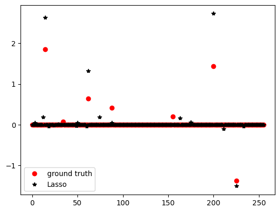

```python
import matplotlib.pyplot as plt
%matplotlib inline

plt.figure()
plt.plot(tPb.theta,'ro',label='ground truth')
plt.plot(theta_l,'k*',label='Lasso')
plt.legend()
plt.show()
```

# Comparing and Improving

> Compute the lasso and Dantzig selector solutions for the same problem and investigate their compared performance graphically and by computing the error on the null and non-null coordinates of theta.

> Play with the values of $n,m,\sigma, S$ to exhibit differences in behaviors.

```python
import toy_problem as tPb
reload(tPb)


theta_l = Lasso(tPb.y,tPb.X,tPb.sigma)
theta_ds = DantzigSelector(tPb.y,tPb.X,tPb.sigma)
```

```
importing notebook from toy_problem.ipynb
     pcost       dcost       gap    pres   dres
 0: -3.1889e+01  1.2402e+02  1e+03  4e+01  3e+00
 1:  1.0072e+02 -8.3705e+00  1e+02  6e-15  3e-15
 2:  2.7510e+01 -7.4972e+00  4e+01  3e-15  1e-15
 3:  8.3599e-01 -6.7715e+00  8e+00  1e-15  7e-16
 4: -4.8714e+00 -6.3272e+00  1e+00  9e-16  7e-16
 5: -6.0433e+00 -6.2384e+00  2e-01  9e-16  7e-16
 6: -6.2119e+00 -6.2275e+00  2e-02  2e-15  1e-15
 7: -6.2262e+00 -6.2265e+00  3e-04  2e-15  4e-15
 8: -6.2264e+00 -6.2264e+00  5e-06  2e-15  9e-14
Optimal solution found.
     pcost       dcost       gap    pres   dres   k/t
 0:  0.0000e+00 -2.1191e+02  2e+03  4e+00  2e+00  1e+00
 1:  4.1574e+00 -2.4898e+01  1e+02  5e-01  3e-01  3e+00
 2:  2.3877e+00 -8.5942e+00  3e+01  2e-01  1e-01  1e+00
 3:  2.1713e+00 -2.8976e+00  1e+01  9e-02  5e-02  4e-01
 4:  2.2007e+00  4.8071e-01  5e+00  3e-02  2e-02  7e-02
 5:  2.2290e+00  8.3961e-01  4e+00  2e-02  1e-02  4e-02
 6:  2.4265e+00  2.1866e+00  6e-01  4e-03  2e-03  3e-03
 7:  2.4715e+00  2.4168e+00  1e-01  9e-04  5e-04  5e-04
 8:  2.4847e+00  2.4826e+00  6e-03  4e-05  2e-05  5e-06
 9:  2.4853e+00  2.4853e+00  6e-05  4e-07  2e-07  5e-08
10:  2.4853e+00  2.4853e+00  6e-07  4e-09  2e-09  5e-10
Optimal solution found.
```

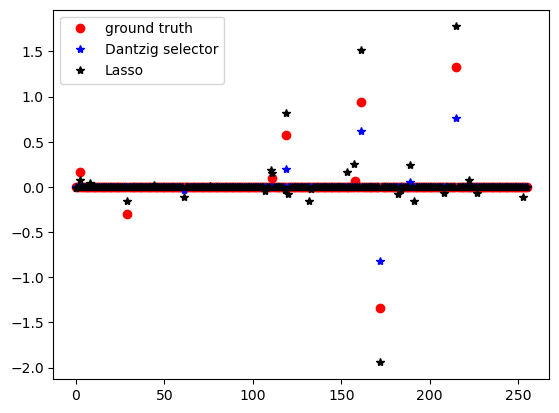

```python
import matplotlib.pyplot as plt
%matplotlib inline

plt.figure()
plt.plot(tPb.theta,'ro',label='ground truth')
plt.plot(theta_ds,'b*',label='Dantzig selector')
plt.plot(theta_l,'k*',label='Lasso')
plt.legend()
plt.show()
```

Let's compute the average error of each method to compare the two methods.

```python
print("Dantzig selector average error", np.mean(abs(tPb.theta - theta_ds)))
print("Lasso average error", np.mean(abs(tPb.theta - theta_l)))
```

```
Dantzig selector average error 0.028126723612251485
Lasso average error 0.04800660586627013
```

We can see that the average error of the Lasso is greater than the average error of the Dantzig selector. The Dantzig selector seems to be better.

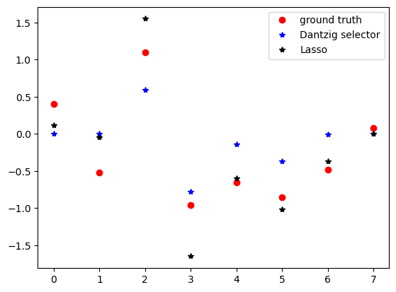

[output not shown]

```python
import matplotlib.pyplot as plt
%matplotlib inline



plt.figure()
plt.plot(tPb.theta[tPb.non_null],'ro',label='ground truth')
plt.plot(np.array(theta_ds)[tPb.non_null],'b*',label='Dantzig selector')
plt.plot(np.array(theta_l)[tPb.non_null],'k*',label='Lasso')
plt.legend()
plt.show()

err_theta_DS = np.linalg.norm(np.array(theta_ds)[tPb.non_null] -tPb.theta[tPb.non_null]  , ord=1)
err_theta_L = np.linalg.norm(np.array(theta_l)[tPb.non_null]-tPb.theta[tPb.non_null] , ord=1)

print("Error on the non-null coefficients\n Dantzig selec. \t Lasso")
print(err_theta_DS,err_theta_L)
```

We can see that the error on the non-null coefficients of the Lasso method is in the same order of the average error of the Dantzig selector. So in the particular case of non-null coefficients estimation both have the same order of accuracy.

```python
err_supp_DS = 0
err_supp_L = 0
for i in range(tPb.n):
    if i not in  tPb.non_null:
        err_supp_DS += np.abs(theta_ds[i])
        err_supp_L += np.abs(theta_l[i])

print("Error on the null coefficients\n Dantzig selec. \t Lasso")
print(float(err_supp_DS),float(err_supp_L))
```

```
Error on the null coefficients
 Dantzig selec. 	 Lasso
0.30727221540609023 2.051808719552942
```

Here, we can see that the cumulative error of the Lasso method in null coefficients is greater than the Dantzig selector. We have a factor of 6 or 7 between the two method and the difference of accuruacy between the two method are much larger than in non-null coefficients. That's mean the Lasso method are less able to flat coefficients to zeros, which could be a problem if the non-null coefficients are close to zero. In this case we should use the Dantzig selector.

This cumulative error is what make the average error of the Lasso method greater than the Dantzig selector despite of its accuracy on non-null coefficients.

```python
print("Error on y \n Dantzig selec. \t Lasso")
print(float(np.linalg.norm(np.dot(tPb.X, theta_ds ) - tPb.y )),float(np.linalg.norm(np.dot(tPb.X, theta_l ) - tPb.y )))
```

```
Error on y
 Dantzig selec. 	 Lasso
22.01112319278166 34.123065081787885
```

```python
print("Quadratic error \n Dantzig selec. \t Lasso")
print(float(np.linalg.norm(np.dot(tPb.X.T , np.dot(tPb.X, theta_ds ) - tPb.y ))),float(np.linalg.norm(np.dot(tPb.X.T , np.dot(tPb.X, theta_l ) - tPb.y ))))
```

```
Quadratic error
 Dantzig selec. 	 Lasso
44.04607724376697 72.85168705382601
```

With the two previous computation, we can see that the error on y and the quadradic error on y are both significantly lower with the Dantzig selector. Which is consistent with all previous comparisons.

```
importing notebook from toy_problem_eleve.ipynb
     pcost       dcost       gap    pres   dres
 0: -5.0857e+02  4.3184e+02  2e+03  6e+01  8e-01
 1:  1.7547e+02 -1.0606e+02  3e+02  2e+00  2e-02
 2:  1.8527e+01 -7.9399e+01  1e+02  4e-01  5e-03
 3: -5.1438e+01 -7.1805e+01  2e+01  4e-02  6e-04
 4: -6.7459e+01 -7.0184e+01  3e+00  4e-03  5e-05
 5: -6.9749e+01 -6.9964e+01  2e-01  2e-04  3e-06
 6: -6.9934e+01 -6.9946e+01  1e-02  2e-06  3e-08
 7: -6.9944e+01 -6.9944e+01  3e-04  4e-08  5e-10
 8: -6.9944e+01 -6.9944e+01  3e-06  4e-10  5e-12
Optimal solution found.
     pcost       dcost       gap    pres   dres   k/t
 0:  0.0000e+00 -8.4765e+02  3e+03  1e+00  2e+00  1e+00
 1:  2.6784e+01 -6.0093e+01  2e+02  1e-01  2e-01  1e+00
 2:  1.3292e+01 -1.8012e+01  5e+01  4e-02  7e-02  4e-01
 3:  1.2831e+01 -6.4223e+00  3e+01  3e-02  5e-02  2e-01
 4:  1.0520e+01  4.2072e+00  1e+01  9e-03  1e-02  5e-02
 5:  9.7432e+00  7.9470e+00  3e+00  3e-03  4e-03  1e-02
 6:  9.4834e+00  9.1250e+00  6e-01  5e-04  8e-04  2e-03
 7:  9.4305e+00  9.3443e+00  1e-01  1e-04  2e-04  5e-04
 8:  9.4157e+00  9.4044e+00  2e-02  2e-05  3e-05  5e-05
 9:  9.4134e+00  9.4133e+00  2e-04  2e-07  3e-07  6e-07
10:  9.4134e+00  9.4134e+00  2e-06  2e-09  3e-09  6e-09
Optimal solution found.
```

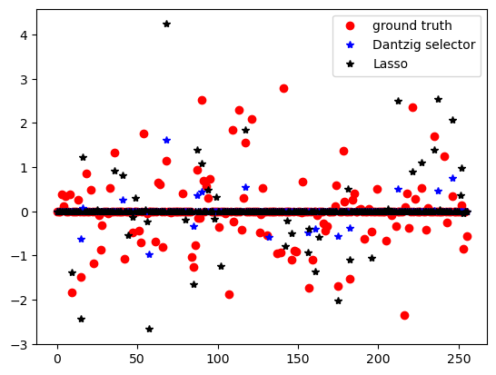

```python
import toy_problem_eleve as tPb
reload(tPb)


theta_l = Lasso(tPb.y,tPb.X,tPb.sigma)
theta_ds = DantzigSelector(tPb.y,tPb.X,tPb.sigma)

import matplotlib.pyplot as plt
%matplotlib inline

plt.figure()
plt.plot(tPb.theta,'ro',label='ground truth')
plt.plot(theta_ds,'b*',label='Dantzig selector')
plt.plot(theta_l,'k*',label='Lasso')
plt.legend()
plt.show()
```

It's hard to try figure out somthing on this messy graph, let's compute some quadratic error

```python
print("Quadratic error \n Dantzig selec. \t Lasso")
print(float(np.linalg.norm(np.dot(tPb.X.T , np.dot(tPb.X, theta_ds ) - tPb.y ))),float(np.linalg.norm(np.dot(tPb.X.T , np.dot(tPb.X, theta_l ) - tPb.y ))))
```

```
Quadratic error
 Dantzig selec. 	 Lasso
163.95209437909807 268.91330969169366
```

Let's compare the two method on their error on the coefficients

```python
err_theta_DS = np.linalg.norm(np.array(theta_ds)[tPb.non_null] -tPb.theta[tPb.non_null]  , ord=1)
err_theta_L = np.linalg.norm(np.array(theta_l)[tPb.non_null]-tPb.theta[tPb.non_null] , ord=1)

print("Error on the non-null coefficients\n Dantzig selec. \t Lasso")
print(err_theta_DS,err_theta_L)

err_supp_DS = 0
err_supp_L = 0
for i in range(tPb.n):
    if i not in  tPb.non_null:
        err_supp_DS += np.abs(theta_ds[i])
        err_supp_L += np.abs(theta_l[i])

print("Error on the null coefficients\n Dantzig selec. \t Lasso")
print(float(err_supp_DS),float(err_supp_L))
```

```
Error on the non-null coefficients
 Dantzig selec. 	 Lasso
353.8852844251389 350.2748056491815
Error on the null coefficients
 Dantzig selec. 	 Lasso
3.7421209123986245 17.483320509541752
```

First we can see that the increase of level noise make the Dantzig selector lose all its avantage in the error on the non-null coefficients. So the Dantzig selector seems to not be more robust to level nose for the computation of non-null coefficients.

So the Dantzig selector still better, but the difference of accuarracy on null coefficients between problems with low level of noise and hight level of noise are more noticible than it is with the Lasso method.

# To go further

### Improved Estimators

A popular improvement of these estimators is to weigh the threshold $\kappa$ with the norm corresponding column of $X$.

The improved Dantzig and Lasso estimators $\widehat{\theta'}_{DS}$ and $\widehat{\theta'}_{L}$ are thus solutions of
$$ \widehat{\theta}_{DS} \in \arg\min_{\theta\in \mathbb{R}^n} \left\{\|\theta\|_1,\;\mbox{with}\;| [ X^T(X\theta-y)]_i | \leq \kappa_i \sigma ~~ \forall i\right\}, $$ and $$ \widehat{\theta}_{L} \in \arg\min_{\theta\in \mathbb{R}^n} \left\{ \|X\theta - y\|_2^2 + \sum_{i=1}^n \kappa_i \sigma |\theta_i | \right\}, $$ where $\kappa_i = \| X_i \|_2 \kappa = \| X_i \|_2 \nu q_{\mathcal{N}} \left(1-\frac{\alpha}{2n}\right) $ where $\| X_i \|_2$ is the $2$-norm of the $i$-th column of $X$.

> Investigate the pertinence of this improvement. (Get rid of the normalization in the problem).

### Crossed Validation of the thresholds

The values of $\kappa$ is heavily linked to the noise standard deviation $\sigma$ and theoretical considerations about $X$ and $\theta$. A practical way to choose $\kappa$ without the knowledge of $\sigma$ is to use *cross-validation*.

- Split y and X in two parts column-wise, one part for *training* and one for *testing*.
- For several values of $\kappa$, solve the estimation problem *on the training part* using $\kappa$ to get a estimate $\widehat{\theta}_\kappa$.
- For each $\widehat{\theta}_\kappa$, compute the error *on the testing part* $e(\kappa) = \| y_{test}-X_{test}\widehat{\theta}_\kappa \|$.
- Choose the value that minimize this error $\widehat{\kappa} = \arg \min_{\kappa} e(\kappa)$.

> Implement a cross validation procedure to choose $\kappa$. Compare the value and the outputted estimate with the theoretic value.